# Surface Area Analysis

Ian Combs – icombs@mote.org

### version: August 12, 2022

#### [GitHub repository](https://github.com/icombs2017/fragGrowthExperiment.git)

This is the working analysis pipeline to analyze data generated from 3D models of micro-fragmented coral colonies and larger frags to assess differences in growth rates between microfragments and natural growth.

### All analyses performed with R version 4.1.0

# Basic setup of R environment

## Loading required packages

For the following analyses we will require the use of a number of different R packages. Most of which can be sourced from CRAN, but some must be downloaded from GitHub. We can use the following code to load in the packages and install any packages not previously installed in the R console.

```r
if (!require("pacman")) install.packages("pacman")
pacman::p_load("ggplot2", "googlesheets4", "dplyr", "officer","reshape2", "stringr", "flextable", "gridExtra", "ggpubr", "Rmisc", "rcompanion", "RColorBrewer", "googledrive", "gdata", "readxl", "DescTools","patchwork", "FSA", "rstatix", "tidyverse", "lme4", 'PMCRMplus', "EnvStats", "emmeans", "MuMIn", "sjstats", "lmerTest")
```

# Importing Data

## We are downloading this dataset from our GoogleDrive folder. We will be using the package `googledrive`. Each GoogleDrive file has a unique ID that does not change throughout the lifespan of the document, even if the file name is changed. This ID is housed in the file’s URL.

Example: docs.google.com/spreadsheets/d/FILE_ID_GOES_HERE/other_information/. Below you will copy and paste that into the function `drive_download` within `as_id`. This will save the file locally in the specified path (in this case our data folder) and you will import the folder as you normally would. Downloading it this way decreases the potential human error when downloading, moving folders, renaming, saving etc and ensures that the most up to date file is being utilized.

# Here we are importing data for D. lab from google drive

```r
drive_download(
  as_id("1C1deEPnb07YcvbEngx_OV3Xl-C740sBefoaum154OyY"),
  path = "../data/saDatasetDL.xlsx",
  overwrite = TRUE)
```

[output not shown]

[output not shown]

[output not shown]

```
## i The googledrive package is using a cached token for 'icombs@mote.org'.
```

[output not shown]

```
## File downloaded:
```

```
## * 'SA Meshlab Data - Kamryn' <id: 1C1deEPnb07YcvbEngx_OV3Xl-C740sBefoaum154OyY>
```

```
## Saved locally as:
```

```
## * '../data/saDatasetDL.xlsx'
```

```r
dlsa <- read_excel("../data/saDatasetDL.xlsx", sheet = 3)

dlsa
```

```
## # A tibble: 36 x 9
##    timepoint species genotype id    trial treatment    SA SAgrowth overallSAGrowth
##    <chr>     <chr>      <dbl> <chr> <dbl> <chr>     <dbl>    <dbl>           <dbl>
##  1 T0        DL             1 DL01      1 wild      254.      NA              NA
##  2 T3        DL             1 DL01      1 wild      259.      NA              NA
##  3 T6        DL             1 DL01      1 wild      269.      14.9            14.9
##  4 T0        DL             1 DL01      1 frag       59.1     NA              NA
##  5 T3        DL             1 DL01      1 frag      115.      NA              NA
##  6 T6        DL             1 DL01      1 frag      183.     124.             NA
##  7 T0        DL             1 DL01      2 frag       68.0     NA              NA
##  8 T3        DL             1 DL01      2 frag       94.3     NA              NA
##  9 T6        DL             1 DL01      2 frag      136.      68.0            NA
## 10 T0        DL             1 DL01      3 frag       75.9     NA              NA
## # ... with 26 more rows
```

#Here we are importing data for P. cli from google drive

```r
drive_download(
  as_id("1C1deEPnb07YcvbEngx_OV3Xl-C740sBefoaum154OyY"),
  path = "../data/saDatasetPC.xlsx",
  overwrite = TRUE)
```

```
## File downloaded:
```

```
## * 'SA Meshlab Data - Kamryn' <id: 1C1deEPnb07YcvbEngx_OV3Xl-C740sBefoaum154OyY>
```

```
## Saved locally as:
```

```
## * '../data/saDatasetPC.xlsx'
```

```r
pcsa <- read_excel("../data/saDatasetPC.xlsx", sheet = 4)

pcsa
```

```
## # A tibble: 36 x 9
##    timepoint species genotype id    trial treatment    SA SAgrowth overallSAGrowth
##    <chr>     <chr>      <dbl> <chr> <dbl> <chr>     <dbl>    <dbl>           <dbl>
##  1 T0        PC            13 PC13      3 wild      218.     NA              NA
##  2 T3        PC            13 PC13      3 wild      222.     NA              NA
##  3 T6        PC            13 PC13      3 wild      224.      6.70            6.70
##  4 T0        PC            13 PC13      1 frag       64.5    NA              NA
##  5 T3        PC            13 PC13      1 frag      143.     NA              NA
##  6 T6        PC            13 PC13      1 frag      195.    130.             NA
##  7 T0        PC            13 PC13      2 frag       73.6    NA              NA
##  8 T3        PC            13 PC13      2 frag      122.     NA              NA
##  9 T6        PC            13 PC13      2 frag      176.    103.             NA
## 10 T0        PC            13 PC13      3 frag       72.4    NA              NA
## # ... with 26 more rows
```

#Here we are importing data for P. str from google drive

```r
drive_download(
  as_id("1C1deEPnb07YcvbEngx_OV3Xl-C740sBefoaum154OyY"),
  path = "../data/saDatasetPS.xlsx",
  overwrite = TRUE)
```

```
## File downloaded:
```

```
## * 'SA Meshlab Data - Kamryn' <id: 1C1deEPnb07YcvbEngx_OV3Xl-C740sBefoaum154OyY>
```

```
## Saved locally as:
```

```
## * '../data/saDatasetPS.xlsx'
```

```r
pssa <- read_excel("../data/saDatasetPS.xlsx", sheet = 5)

pssa
```

```
## # A tibble: 60 x 9
##    timepoint species genotype id    trial treatment    SA SAgrowth overallSAGrowth
##    <chr>     <chr>      <dbl> <chr> <dbl> <chr>     <dbl>    <dbl>           <dbl>
##  1 T0        PS             7 PS07      3 wild      161.      NA              NA
##  2 T3        PS             7 PS07      3 wild      180.      NA              NA
##  3 T6        PS             7 PS07      3 wild      195.      34.3            34.3
##  4 T0        PS             7 PS07      1 frag       64.4     NA              NA
##  5 T3        PS             7 PS07      1 frag      106.      NA              NA
##  6 T6        PS             7 PS07      1 frag      145.      80.3            NA
##  7 T0        PS             7 PS07      2 frag       69.4     NA              NA
##  8 T3        PS             7 PS07      2 frag      100.      NA              NA
##  9 T6        PS             7 PS07      2 frag      150.      80.4            NA
## 10 T0        PS             7 PS07      3 frag       71.8     NA              NA
## # ... with 50 more rows
```

```r
drive_download(
  as_id("1C1deEPnb07YcvbEngx_OV3Xl-C740sBefoaum154OyY"),
  path = "../data/saDatasetTotal.xlsx",
  overwrite = TRUE)
```

```
## File downloaded:
```

```
## * 'SA Meshlab Data - Kamryn' <id: 1C1deEPnb07YcvbEngx_OV3Xl-C740sBefoaum154OyY>
```

```
## Saved locally as:
```

```
## * '../data/saDatasetTotal.xlsx'
```

```r
total <- read_excel("../data/saDatasetTotal.xlsx", sheet = 1)

total
```

```
## # A tibble: 132 x 15
##    timePoint species genotype id    trial treatment `scale 1` `scale 2` `scale 3`
##    <chr>     <chr>      <dbl> <chr> <dbl> <chr>         <dbl>     <dbl>     <dbl>
##  1 initial   DL             1 DL1       1 wild          1.27      1.18      1.21
##  2 initial   PC            16 PC16      1 wild          0.227     0.227     0.237
##  3 initial   PS            13 PS13      1 wild          1.87      1.86      1.84
##  4 initial   PS            14 PS14      1 wild          1.77      1.82      1.77
##  5 initial   DL             1 DL1       1 frag          2.02      1.93      2.00
##  6 initial   DL             2 DL2       1 frag          1.19      1.21      1.21
##  7 initial   DL             3 DL3       1 frag          0.707     0.709     0.712
##  8 initial   PC            13 PC13      1 frag          1.44      1.43      1.46
##  9 initial   PC            15 PC15      1 frag          1.01      0.987     1.01
## 10 initial   PC            16 PC16      1 frag          1.05      1.00      1.00
## # ... with 122 more rows, and 6 more variables: average <dbl>, scaleFactor <dbl>,
## #   surfaceArea (cm^2) <dbl>, ryanSA <dbl>, notes <chr>, t6-t0 <dbl>
```

```r
dlsaClean <- dlsa %>%
  select("timepoint", "species", "genotype","id","trial","treatment","SA")




dlsaClean$timepoint <- as.factor(dlsaClean$timepoint)

dlsaClean$species <- as.factor(dlsaClean$species)

dlsaClean$id <- as.factor(dlsaClean$id)

dlsaClean$trial <- as.factor(dlsaClean$trial)

dlsaClean$treatment <- as.factor(dlsaClean$treatment)



head(dlsaClean)
```

```
## # A tibble: 6 x 7
##   timepoint species genotype id    trial treatment    SA
##   <fct>     <fct>      <dbl> <fct> <fct> <fct>     <dbl>
## 1 T0        DL             1 DL01  1     wild      254.
## 2 T3        DL             1 DL01  1     wild      259.
## 3 T6        DL             1 DL01  1     wild      269.
## 4 T0        DL             1 DL01  1     frag       59.1
## 5 T3        DL             1 DL01  1     frag      115.
## 6 T6        DL             1 DL01  1     frag      183.
```

```r
pcsaClean <- pcsa %>%
  select("timepoint", "species", "genotype","id","trial","treatment","SA")




pcsaClean$timepoint <- as.factor(pcsaClean$timepoint)

pcsaClean$species <- as.factor(pcsaClean$species)

pcsaClean$id <- as.factor(pcsaClean$id)

pcsaClean$trial <- as.factor(pcsaClean$trial)

pcsaClean$treatment <- as.factor(pcsaClean$treatment)



head(pcsaClean)
```

```
## # A tibble: 6 x 7
##   timepoint species genotype id    trial treatment    SA
##   <fct>     <fct>      <dbl> <fct> <fct> <fct>     <dbl>
## 1 T0        PC            13 PC13  3     wild      218.
## 2 T3        PC            13 PC13  3     wild      222.
## 3 T6        PC            13 PC13  3     wild      224.
## 4 T0        PC            13 PC13  1     frag       64.5
## 5 T3        PC            13 PC13  1     frag      143.
## 6 T6        PC            13 PC13  1     frag      195.
```

```r
pssaClean <- pssa %>%
  select("timepoint", "species", "genotype","id","trial","treatment","SA")




pssaClean$timepoint <- as.factor(pssaClean$timepoint)

pssaClean$species <- as.factor(pssaClean$species)

pssaClean$id <- as.factor(pssaClean$id)

pssaClean$trial <- as.factor(pssaClean$trial)

pssaClean$treatment <- as.factor(pssaClean$treatment)



head(pssaClean)
```

```
## # A tibble: 6 x 7
##   timepoint species genotype id    trial treatment    SA
##   <fct>     <fct>      <dbl> <fct> <fct> <fct>     <dbl>
## 1 T0        PS             7 PS07  3     wild      161.
## 2 T3        PS             7 PS07  3     wild      180.
## 3 T6        PS             7 PS07  3     wild      195.
## 4 T0        PS             7 PS07  1     frag       64.4
## 5 T3        PS             7 PS07  1     frag      106.
## 6 T6        PS             7 PS07  1     frag      145.
```

```r
totalClean <- total %>%
  select("timePoint", "species", "id","trial","treatment","surfaceArea (cm^2)") %>%
  filter(species %in% c("DL", "PC", "PS")) %>%
  filter(timePoint %in% c("initial", "T3", "T6")) %>%
  dplyr::rename("SA" = "surfaceArea (cm^2)")


  totalClean$timePoint <- gsub("initial", "T0", totalClean$timePoint)


totalClean$timepoint <- as.factor(totalClean$timePoint)

totalClean$species <- as.factor(totalClean$species)

totalClean$id <- as.factor(totalClean$id)

totalClean$trial <- as.factor(totalClean$trial)

totalClean$treatment <- as.factor(totalClean$treatment)
```

### Here we are breaking the data apart into frags and wilds for dl, pc, and ps, combinging the frags from each trial, putting the data back together, and then calculating percent change of surface area between the first and last timepoint. We are using a number of functions from the package `dplyr` as well as the function `dcast()` to recombine data from the package `reshape2`

```r
dlsaFrag <- dlsaClean %>%
  select(timepoint, species, id, treatment, SA) %>%
  dplyr::filter(treatment %in% 'frag') %>%
  dplyr::group_by(timepoint, species, id, treatment) %>%
  dplyr::summarise(sum(SA)) %>%
  dplyr::rename("SA" = "sum(SA)")
dlsaWild <- dlsaClean %>%
  dplyr::filter(treatment %in% 'wild') %>%
  select(timepoint, species, id, treatment, SA)


dlsaCombo <- bind_rows(dlsaFrag,dlsaWild)

dlsaFinal <- dlsaCombo %>%
  dplyr::filter(timepoint %in% c("T0","T3","T6")) %>%
  select(c('timepoint','species','id','treatment', "SA"))



dlsaChange <- dcast(dlsaFinal, id+treatment~timepoint)
dlsaChange <- dplyr::rename(dlsaChange, "initialSurfaceArea" = "T0", "finalSurfaceArea" = "T6")
dlsaChange
```

```
##     id treatment initialSurfaceArea       T3 finalSurfaceArea
## 1 DL01      frag           203.0350 306.9212         499.6702
## 2 DL01      wild           253.7979 259.0732         268.6627
## 3 DL02      frag           221.0378 351.6254         596.5135
## 4 DL02      wild           253.2529 254.4126         291.5471
## 5 DL03      frag           239.2059 346.5453         496.6865
## 6 DL03      wild           261.4239 305.1549         372.1441
```

```r
dlsaChange$difference <- (dlsaChange$finalSurfaceArea-dlsaChange$initialSurfaceArea)
dlsaChange$percentChange <- ((dlsaChange$finalSurfaceArea-dlsaChange$initialSurfaceArea)/dlsaChange$initialSurfaceArea)*100
```

```r
pcsaFrag <- pcsaClean %>%
  select(timepoint, species, id, treatment, SA) %>%
  dplyr::filter(treatment %in% 'frag') %>%
  dplyr::group_by(timepoint, species, id, treatment) %>%
  dplyr::summarise(sum(SA)) %>%
  dplyr::rename("SA" = "sum(SA)")
pcsaWild <- pcsaClean %>%
  dplyr::filter(treatment %in% 'wild') %>%
  select(timepoint, species, id, treatment, SA)


pcsaCombo <- bind_rows(pcsaFrag,pcsaWild)

pcsaFinal <- pcsaCombo %>%
  dplyr::filter(timepoint %in% c("T0","T3","T6")) %>%
  select(c('timepoint','species','id','treatment', "SA"))



pcsaChange <- dcast(pcsaFinal, id+treatment~timepoint)
pcsaChange <- dplyr::rename(pcsaChange, "initialSurfaceArea" = "T0", "finalSurfaceArea" = "T6")
pcsaChange
```

```
##     id treatment initialSurfaceArea       T3 finalSurfaceArea
## 1 PC13      frag           210.5453 412.7654         555.4986
## 2 PC13      wild           217.6633 221.6812         224.3588
## 3 PC15      frag           197.1018 370.9282         442.2799
## 4 PC15      wild           184.7113 187.0033         198.9763
## 5 PC16      frag           231.2059 389.6948         473.3982
## 6 PC16      wild           218.8646 231.4750         236.5812
```

```r
pcsaChange$difference <- (pcsaChange$finalSurfaceArea-pcsaChange$initialSurfaceArea)
pcsaChange$percentChange <- ((pcsaChange$finalSurfaceArea-pcsaChange$initialSurfaceArea)/pcsaChange$initialSurfaceArea)*100
```

```r
pssaFrag <- pssaClean %>%
  select(timepoint, species, id, treatment, SA) %>%
  dplyr::filter(treatment %in% 'frag') %>%
  dplyr::group_by(timepoint, species, id, treatment) %>%
  dplyr::summarise(sum(SA)) %>%
  dplyr::rename("SA" = "sum(SA)")
pssaWild <- pssaClean %>%
  dplyr::filter(treatment %in% 'wild') %>%
  select(timepoint, species, id, treatment, SA)


pssaCombo <- bind_rows(pssaFrag,pssaWild)

pssaFinal <- pssaCombo %>%
  dplyr::filter(timepoint %in% c("T0","T3","T6")) %>%
  select(c('timepoint','species','id','treatment', "SA"))



pssaChange <- dcast(pssaFinal, id+treatment~timepoint)
pssaChange <- dplyr::rename(pssaChange, "initialSurfaceArea" = "T0", "finalSurfaceArea" = "T6")
pssaChange
```

```
##      id treatment initialSurfaceArea        T3 finalSurfaceArea
## 1  PS07      frag          205.52574 317.15226         463.1965
## 2  PS07      wild          160.97325 180.48955         195.2593
## 3  PS11      frag           76.22869 118.66103         169.3028
## 4  PS11      wild           83.89181  90.15424         104.5236
## 5  PS12      frag          169.81064 195.55062         309.2690
## 6  PS12      wild          169.72485 171.27461         172.1972
## 7  PS13      frag          203.64457 334.09838         454.0648
## 8  PS13      wild          216.01222 254.33131         256.2334
## 9  PS14      frag          296.49663 487.75380         662.1317
## 10 PS14      wild          212.76254 259.99365         294.9398
```

```r
pssaChange$difference <- (pssaChange$finalSurfaceArea-pssaChange$initialSurfaceArea)
pssaChange$percentChange <- ((pssaChange$finalSurfaceArea-pssaChange$initialSurfaceArea)/pssaChange$initialSurfaceArea)*100
```

```r
totalFrag <- totalClean %>%
  select(timepoint, species, id, treatment, SA) %>%
  dplyr::filter(treatment %in% 'frag') %>%
  dplyr::group_by(timepoint, species, id, treatment) %>%
  dplyr::summarise(sum(SA)) %>%
  dplyr::rename("SA" = "sum(SA)")
totalWild <- totalClean %>%
  dplyr::filter(treatment %in% 'wild') %>%
  select(timepoint, species, id, treatment, SA)

totalCombo <- bind_rows(totalFrag,totalWild)

totalFinal <- totalCombo %>%
  dplyr::filter(timepoint %in% c("T0","T3","T6")) %>%
  select(c('timepoint','species','id','treatment', "SA"))



totalChange <- dcast(totalFinal, id+treatment~timepoint)
totalChange <- dplyr::rename(totalChange, "initialSurfaceArea" = "T0", "finalSurfaceArea" = "T6")
totalChange
```

```
##      id treatment initialSurfaceArea        T3 finalSurfaceArea
## 1   DL1      frag          203.03502 306.92122         498.6896
## 2   DL1      wild          253.79788 259.07324         268.6627
## 3   DL2      frag          221.03780 351.62540         596.5135
## 4   DL2      wild          253.25295 254.41258         291.5471
## 5   DL3      frag          239.20594 346.54534         496.6865
## 6   DL3      wild          261.42386 305.15491         372.1441
## 7  PC13      frag          210.54533 412.76543         555.4986
## 8  PC13      wild          217.66332 221.68120         224.3588
## 9  PC15      frag          197.10185 370.92823         442.2799
## 10 PC15      wild          184.71132 187.00331         198.9763
## 11 PC16      frag          231.20586 389.69478         473.3982
## 12 PC16      wild          218.86459 231.47499         236.5812
## 13 PS11      frag           76.22869 118.66103         169.3028
## 14 PS11      wild           83.89181  90.15424         104.5236
## 15 PS12      frag          169.81064 195.55062         309.2690
## 16 PS12      wild          169.72485 171.27461         172.1972
## 17 PS13      frag          203.64457 334.09838         454.0648
## 18 PS13      wild          216.01222 254.33131         256.2334
## 19 PS14      frag          296.49663 487.75380         662.1317
## 20 PS14      wild          212.76254 259.99365         294.9398
## 21  PS7      frag          205.52574 317.15226         463.1965
## 22  PS7      wild          160.97325 180.48955         195.2593
```

```r
totalChange$difference <- (totalChange$finalSurfaceArea-totalChange$initialSurfaceArea)
totalChange$percentChange <- ((totalChange$finalSurfaceArea-totalChange$initialSurfaceArea)/totalChange$initialSurfaceArea)*100
```

#Here we are creating percent change figures for dl, pc, and ps using ‘ggplot’

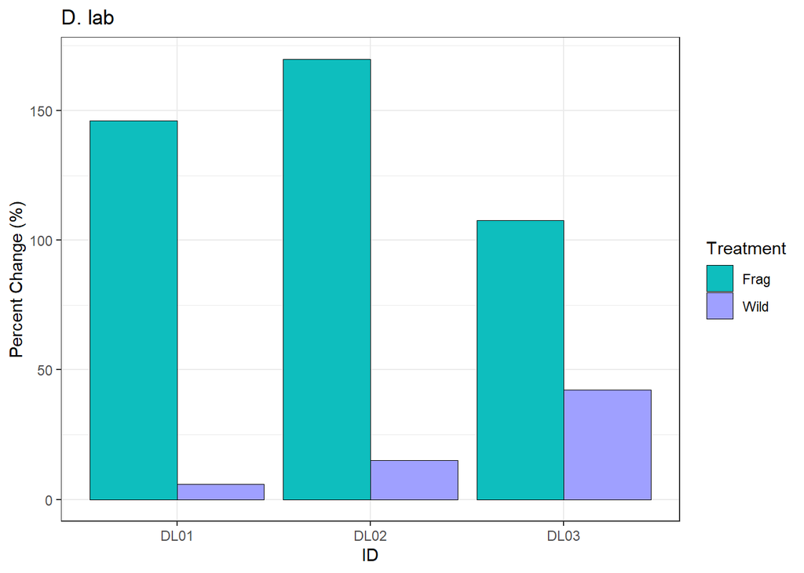

```r
dlSApercentChange.1 <- ggplot(data=dlsaChange, aes(x=id, y=percentChange, fill=treatment)) +
    geom_bar(colour="black", stat="identity",
             position=position_dodge(),
             size=.3) +  scale_fill_manual(name="Treatment",labels=c('Frag', 'Wild'),values = c("#0EBEBE","#9FA0FF")) +
    xlab("ID") + ylab("Percent Change (%)") +
    ggtitle("D. lab") +
    theme_bw()


dlSApercentChange <- dlSApercentChange.1 + theme(
  panel.grid.major = element_line(size = 0.5, linetype = 'solid', colour = "white"),
  panel.background = element_rect(fill = '#F5F5F5'),
  plot.title = element_text(hjust = 0.5),
  axis.line = element_line(colour = "black"),
  axis.ticks = element_line(color="black"),
  text = element_text(size = 22, color="black"),
  axis.text.x=element_text(size = 18, color="black"),
  axis.text.y=element_text(size = 18, color="black"),
  legend.position = "right")

dlSApercentChange.1
```

```r
ggsave("../figures/dlPercentSAgrowth.png", plot = dlSApercentChange, height = 5, width = 9, units = 'in',dpi = 600)
```

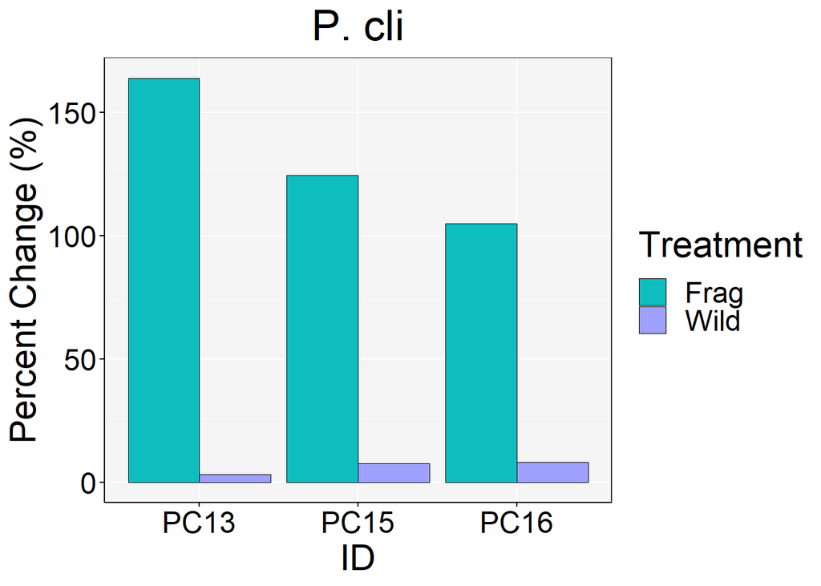

```r
pcSApercentChange.1 <- ggplot(data=pcsaChange, aes(x=id, y=percentChange, fill=treatment)) +
    geom_bar(colour="black", stat="identity",
             position=position_dodge(),
             size=.3) + scale_fill_manual(name="Treatment",labels=c('Frag', 'Wild'),values = c("#0EBEBE","#9FA0FF")) +
    xlab("ID") + ylab("Percent Change (%)") + # Set axis labels
    ggtitle("P. cli") +     # Set title
    theme_bw()

pcSApercentChange <- pcSApercentChange.1 + theme(
  panel.grid.major = element_line(size = 0.5, linetype = 'solid', colour = "white"),
  panel.background = element_rect(fill = '#F5F5F5'),
  plot.title = element_text(hjust = 0.5),
  axis.line = element_line(colour = "black"),
  axis.ticks = element_line(color="black"),
  text = element_text(size = 22, color="black"),
  axis.text.x=element_text(size = 18, color="black"),
  axis.text.y=element_text(size = 18, color="black"),
  legend.position = "right")

pcSApercentChange
```

```r
ggsave("../figures/pcPercentSAgrowth.png", plot = pcSApercentChange, height = 5, width = 9, units = 'in',dpi = 600)
```

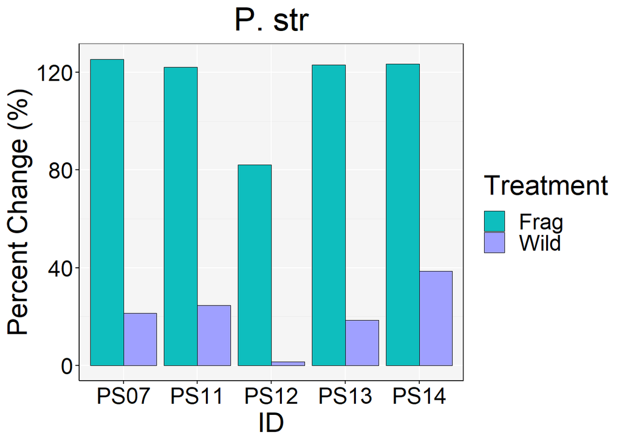

```r
psSApercentChange.1 <- ggplot(data=pssaChange, aes(x=id, y=percentChange, fill=treatment)) +
    geom_bar(colour="black", stat="identity",
             position=position_dodge(),
             size=.3) +scale_fill_manual(name="Treatment",labels=c('Frag', 'Wild'),values = c("#0EBEBE","#9FA0FF"))+
    xlab("ID") + ylab("Percent Change (%)") +
    ggtitle("P. str") +
    theme_bw()

psSApercentChange <- psSApercentChange.1 + theme(
  panel.grid.major = element_line(size = 0.5, linetype = 'solid', colour = "white"),
  panel.background = element_rect(fill = '#F5F5F5'),
  plot.title = element_text(hjust = 0.5),
  axis.line = element_line(colour = "black"),
  axis.ticks = element_line(color="black"),
  text = element_text(size = 22, color="black"),
  axis.text.x=element_text(size = 18, color="black"),
  axis.text.y=element_text(size = 18, color="black"),
  legend.position = "right")

psSApercentChange
```

```r
ggsave("../figures/psPercentSAgrowth.png", plot = psSApercentChange, height = 5, width = 9, units = 'in',dpi = 600)
```

#Here we are creating a change in surface area figure for dl, pc, and ps using ‘ggplot’

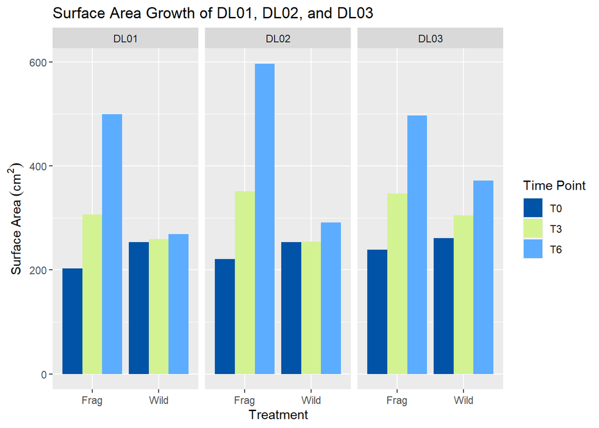

```r
dlSAgrowthGenotype.1 <- ggplot(data=dlsaFinal, aes(x = treatment, y = SA, fill = timepoint)) +
  geom_bar(stat = "identity", position = position_dodge())+
  facet_wrap(~id)+
  scale_fill_hue(name="Time Point") +
  labs(x = "Treatment", y = bquote("Surface Area" ~ (cm^2)),fill='Time Point') +
    ggtitle("Surface Area Growth of DL01, DL02, and DL03") + scale_fill_discrete(labels=c('Initial','T3','Final'))+scale_x_discrete(labels=c("frag" = "Frag", "wild" = "Wild"))+scale_fill_manual(values = c("#0053A6", "#D3F292", "#5CADFF"))
dlSAgrowthGenotype.1
```

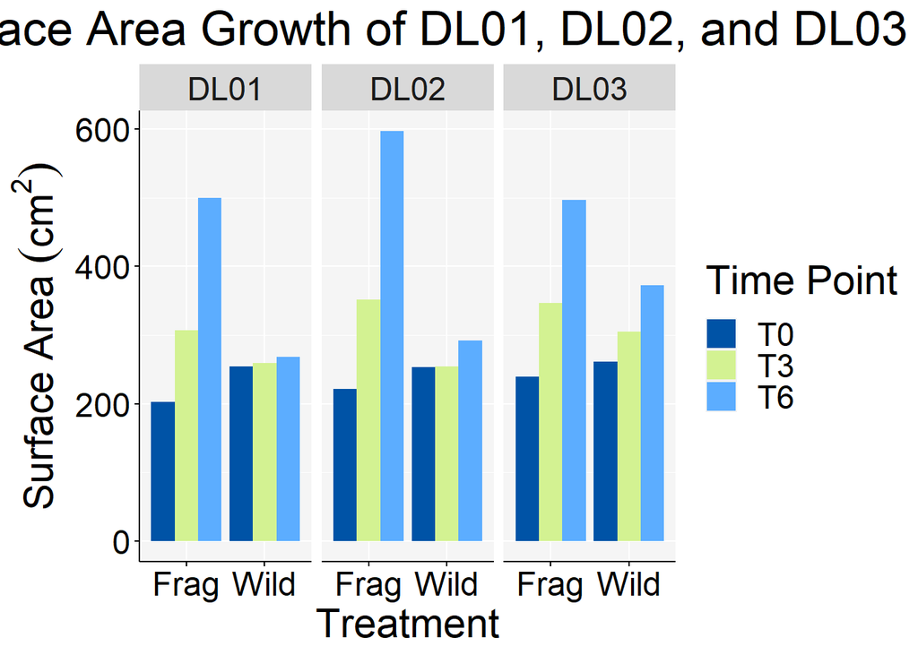

```r
dlSAgrowthGenotype <- dlSAgrowthGenotype.1 + theme(
  panel.grid.major = element_line(size = 0.5, linetype = 'solid', colour = "white"),
  panel.background = element_rect(fill = '#F5F5F5'),
  plot.title = element_text(hjust = 0.5),
  axis.line = element_line(colour = "black"),
  axis.ticks = element_line(color="black"),
  text = element_text(size = 22, color="black"),
  axis.text.x=element_text(size = 18, color="black"),
  axis.text.y=element_text(size = 18, color="black"),
  legend.position = "right")


dlSAgrowthGenotype
```

```r
ggsave("../figures/dlSAgrowth.png", plot = dlSAgrowthGenotype, height = 5, width = 9, units = 'in',dpi = 600)
```

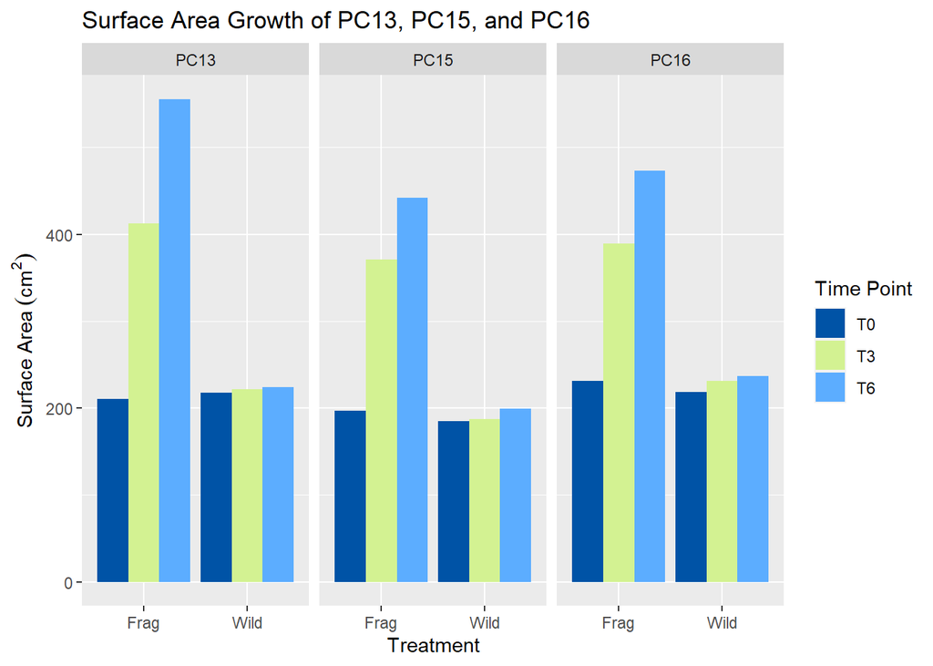

```r
pcSAgrowthGenotype.1 <- ggplot(data=pcsaFinal, aes(x = treatment, y = SA, fill = timepoint)) +
  geom_bar(stat = "identity", position = position_dodge())+
  facet_wrap(~id)+
  scale_fill_hue(name="Time Point") +
  labs(x = "Treatment", y = bquote("Surface Area" ~ (cm^2)),fill='Time Point') +
    ggtitle("Surface Area Growth of PC13, PC15, and PC16") + scale_fill_discrete(labels=c('Initial','T3','Final'))+scale_x_discrete(labels=c("frag" = "Frag", "wild" = "Wild"))+scale_fill_manual(values = c("#0053A6", "#D3F292", "#5CADFF"))
pcSAgrowthGenotype.1
```

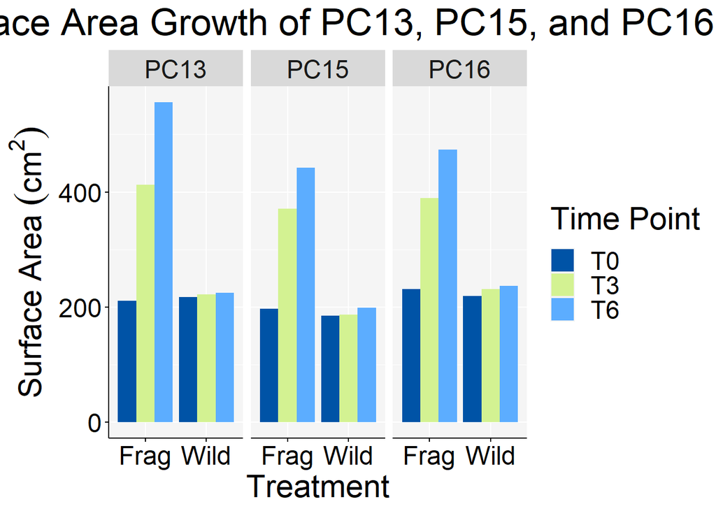

```r
pcSAgrowthGenotype <- pcSAgrowthGenotype.1 + theme(
  panel.grid.major = element_line(size = 0.5, linetype = 'solid', colour = "white"),
  panel.background = element_rect(fill = '#F5F5F5'),
  plot.title = element_text(hjust = 0.5),
  axis.line = element_line(colour = "black"),
  axis.ticks = element_line(color="black"),
  text = element_text(size = 22, color="black"),
  axis.text.x=element_text(size = 18, color="black"),
  axis.text.y=element_text(size = 18, color="black"),
  legend.position = "right")


pcSAgrowthGenotype
```

```r
ggsave("../figures/pcSAgrowth.png", plot = pcSAgrowthGenotype, height = 5, width = 9, units = 'in',dpi = 600)
```

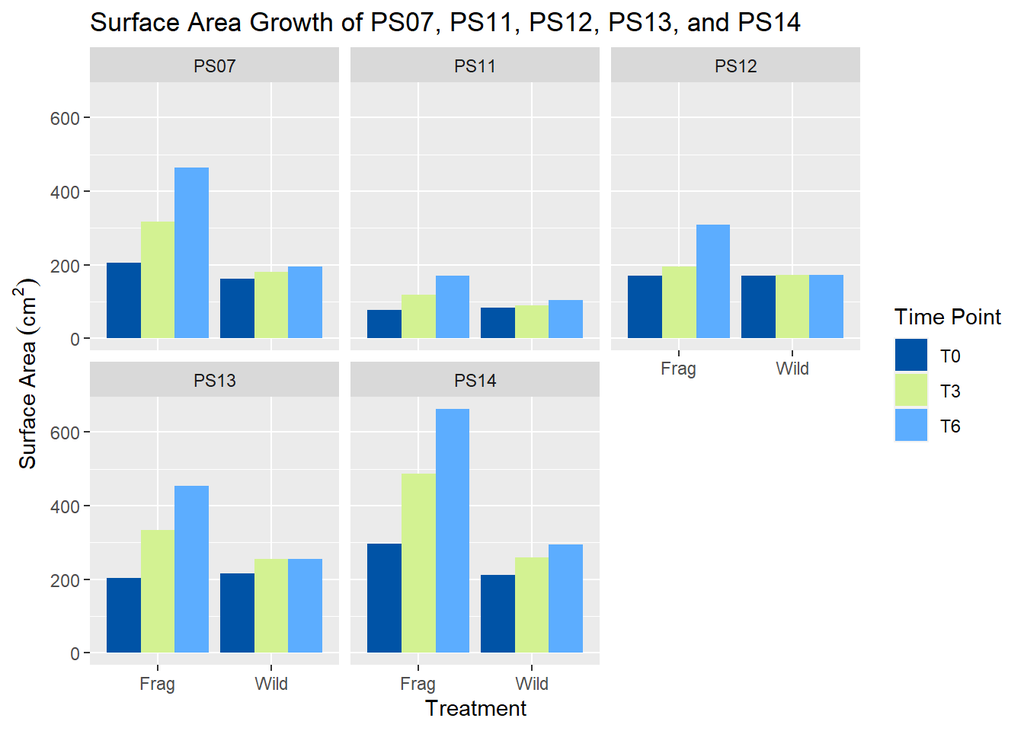

```r
psSAgrowthGenotype.1 <- ggplot(data=pssaFinal, aes(x = treatment, y = SA, fill = timepoint)) +
  geom_bar(stat = "identity", position = position_dodge())+
  facet_wrap(~id)+
  scale_fill_hue(name="Time Point") +
  labs(x = "Treatment", y = bquote("Surface Area" ~ (cm^2)),fill='Time Point') +
    ggtitle("Surface Area Growth of PS07, PS11, PS12, PS13, and PS14") + scale_fill_discrete(labels=c('Initial','T3','Final'))+scale_x_discrete(labels=c("frag" = "Frag", "wild" = "Wild"))+scale_fill_manual(values = c("#0053A6", "#D3F292", "#5CADFF"))
psSAgrowthGenotype.1
```

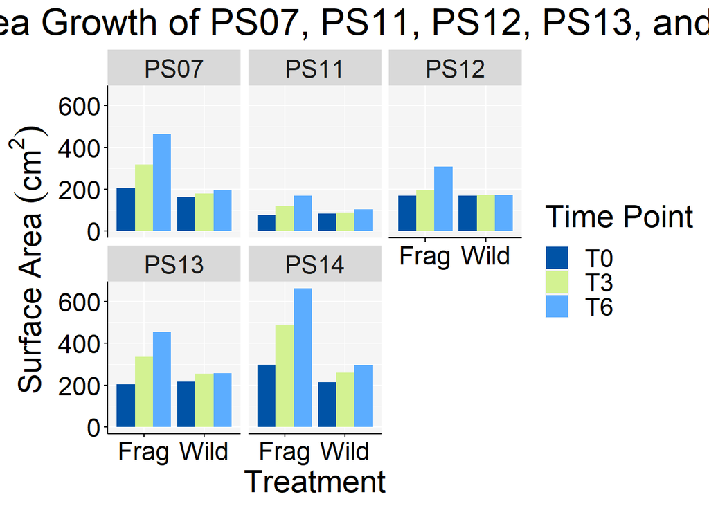

```r
psSAgrowthGenotype <- psSAgrowthGenotype.1 + theme(
  panel.grid.major = element_line(size = 0.5, linetype = 'solid', colour = "white"),
  panel.background = element_rect(fill = '#F5F5F5'),
  plot.title = element_text(hjust = 0.5),
  axis.line = element_line(colour = "black"),
  axis.ticks = element_line(color="black"),
  text = element_text(size = 22, color="black"),
  axis.text.x=element_text(size = 18, color="black"),
  axis.text.y=element_text(size = 18, color="black"),
  legend.position = "right")


psSAgrowthGenotype
```

```r
ggsave("../figures/psSAgrowth.png", plot = psSAgrowthGenotype, height = 10, width = 15, units = 'in',dpi = 600)
```

#Here we are combining all of the surface area percent change figures (grouped by species)

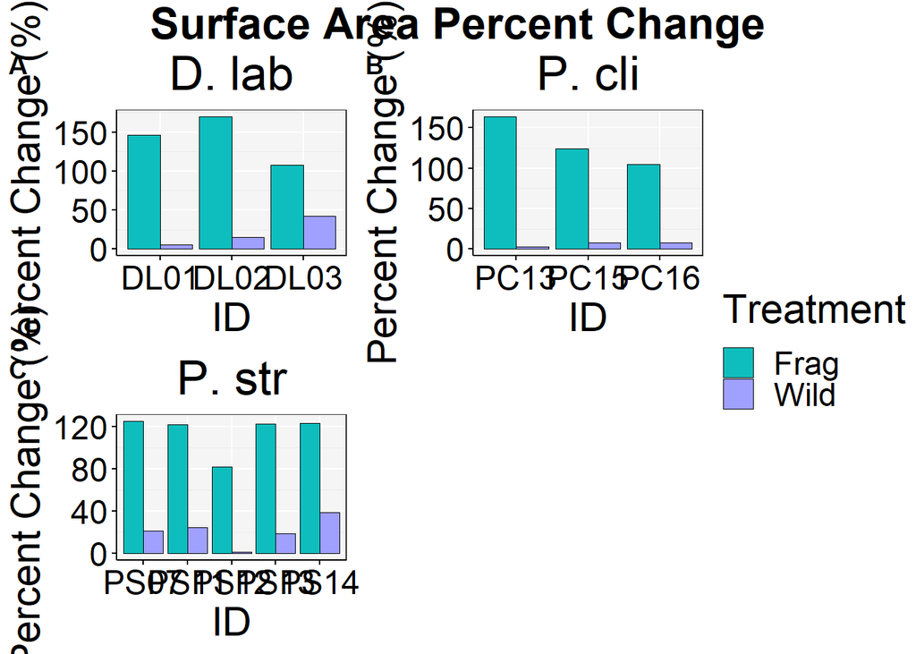

```r
library(ggplot2)
library(ggpubr)
theme_set(theme_pubr())

percentChange <- ggarrange(dlSApercentChange, pcSApercentChange, psSApercentChange,
                    labels = c("A", "B", "C"),
                    ncol = 2, nrow = 2, common.legend = TRUE, legend = "right")
percentChange <- annotate_figure(
  percentChange,
  top = text_grob("Surface Area Percent Change",
                  color = "black", face = "bold", size = 24))


percentChange
```

```r
ggsave("../figures/percentChange.png", plot = percentChange, height = 15, width = 20, units = 'in',dpi = 600)
```

```r
dlsaFragTest <- dlsaChange %>%
  select(id, treatment, percentChange) %>%
  dplyr::filter(treatment %in% 'frag') %>%
  dplyr::group_by(id,treatment)

dlsaWildTest <- dlsaChange %>%
  dplyr::filter(treatment %in% 'wild') %>%
  select(id, treatment, percentChange)

dlsaTest <- left_join(dlsaFragTest, dlsaWildTest, by = c("id"), copy = FALSE) %>%
  dplyr::rename(fragpercentChange = percentChange.x) %>%
  dplyr::rename(wildpercentChange = percentChange.y)
```

```r
pcsaFragTest <- pcsaChange %>%
  select(id, treatment, percentChange) %>%
  dplyr::filter(treatment %in% 'frag') %>%
  dplyr::group_by(id,treatment)

pcsaWildTest <- pcsaChange %>%
  dplyr::filter(treatment %in% 'wild') %>%
  select(id, treatment, percentChange)

pcsaTest <- left_join(pcsaFragTest, pcsaWildTest, by = c("id"), copy = FALSE) %>%
  dplyr::rename(pcfragpercentChange = percentChange.x) %>%
  dplyr::rename(pcwildpercentChange = percentChange.y)
```

```r
pssaFragTest <- pssaChange %>%
  select(id, treatment, percentChange) %>%
  dplyr::filter(treatment %in% 'frag') %>%
  dplyr::group_by(id,treatment)

pssaWildTest <- pssaChange %>%
  dplyr::filter(treatment %in% 'wild') %>%
  select(id, treatment, percentChange)

pssaTest <- left_join(pssaFragTest, pssaWildTest, by = c("id"), copy = FALSE) %>%
  dplyr::rename(psfragpercentChange = percentChange.x) %>%
  dplyr::rename(pswildpercentChange = percentChange.y)
```

# Combining Data

## We are going to combine all of the data we’ve parsed out above into two larger data frames. One for the raw surface area numbers `totalSA` and the other for the percent change data `totalChange`. The latter of which requires a bit more intensive data manipulation because we are calculating percent change of two different timepoints, and combining those data. All of this is done using `dplyr` and `reshape2`.

```r
# Combining the smaller data sets above into two larger data sets
totalSA <- bind_rows(dlsaFinal, pcsaFinal, pssaFinal)
totalClean <- bind_rows(dlsaClean, pcsaClean, pssaClean)

# Now we need to take totalClean and calculate percent change from our two time points.
# But first we need to separate them out into frags and wilds

# Separating into Frags because we need to add up the trials
totalFrag <- totalClean %>%
  select(timepoint, species, id, treatment, SA) %>%
  dplyr::filter(treatment %in% 'frag') %>%
  dplyr::group_by(timepoint, species, id, treatment) %>%
  dplyr::summarise(sum(SA)) %>%
  dplyr::rename("SA" = "sum(SA)")
# Separating into wilds
totalWild <- totalClean %>%
  dplyr::filter(treatment %in% 'wild') %>%
  select(timepoint, species, id, treatment, SA)

# Combining the two back together
totalCombo <- bind_rows(totalFrag,totalWild)

# Now we are separating out each bracket of time points so we can calculate Percent change from T0 to T3 and T0 to T6.

totalT3 <- totalCombo %>%
  dplyr::filter(timepoint %in% c("T0","T3")) %>%
  select(c('timepoint','species','id','treatment', "SA"))

totalT6 <- totalCombo %>%
  dplyr::filter(timepoint %in% c("T0","T6")) %>%
  select(c('timepoint','species','id','treatment', "SA"))

# Going from long to wide so we can do the calculation
totalChangeT3 <- dcast(totalT3,id+species+treatment~timepoint)
# Calculating Percent Change
totalChangeT3 <- dplyr::rename(totalChangeT3, "initialSurfaceArea" = "T0", "T3SurfaceArea" = "T3")
totalChangeT3
```

```
##      id species treatment initialSurfaceArea T3SurfaceArea
## 1  DL01      DL      frag          203.03502     306.92122
## 2  DL01      DL      wild          253.79788     259.07324
## 3  DL02      DL      frag          221.03780     351.62540
## 4  DL02      DL      wild          253.25295     254.41258
## 5  DL03      DL      frag          239.20594     346.54534
## 6  DL03      DL      wild          261.42386     305.15491
## 7  PC13      PC      frag          210.54533     412.76543
## 8  PC13      PC      wild          217.66332     221.68120
## 9  PC15      PC      frag          197.10185     370.92823
## 10 PC15      PC      wild          184.71132     187.00331
## 11 PC16      PC      frag          231.20586     389.69478
## 12 PC16      PC      wild          218.86459     231.47499
## 13 PS07      PS      frag          205.52574     317.15226
## 14 PS07      PS      wild          160.97325     180.48955
## 15 PS11      PS      frag           76.22869     118.66103
## 16 PS11      PS      wild           83.89181      90.15424
## 17 PS12      PS      frag          169.81064     195.55062
## 18 PS12      PS      wild          169.72485     171.27461
## 19 PS13      PS      frag          203.64457     334.09838
## 20 PS13      PS      wild          216.01222     254.33131
## 21 PS14      PS      frag          296.49663     487.75380
## 22 PS14      PS      wild          212.76254     259.99365
```

```r
totalChangeT3$difference <- (totalChangeT3$T3SurfaceArea-totalChangeT3$initialSurfaceArea)
totalChangeT3$T3percentChange <- ((totalChangeT3$T3SurfaceArea-totalChangeT3$initialSurfaceArea)/totalChangeT3$initialSurfaceArea)*100

# Going from long to wide so we can do the calculation
totalChangeT6 <- dcast(totalT6, id+species+treatment~timepoint)
# Calculating Percent Change
totalChangeT6 <- dplyr::rename(totalChangeT6, "initialSurfaceArea" = "T0", "finalSurfaceArea" = "T6")
totalChangeT6
```

```
##      id species treatment initialSurfaceArea finalSurfaceArea
## 1  DL01      DL      frag          203.03502         499.6702
## 2  DL01      DL      wild          253.79788         268.6627
## 3  DL02      DL      frag          221.03780         596.5135
## 4  DL02      DL      wild          253.25295         291.5471
## 5  DL03      DL      frag          239.20594         496.6865
## 6  DL03      DL      wild          261.42386         372.1441
## 7  PC13      PC      frag          210.54533         555.4986
## 8  PC13      PC      wild          217.66332         224.3588
## 9  PC15      PC      frag          197.10185         442.2799
## 10 PC15      PC      wild          184.71132         198.9763
## 11 PC16      PC      frag          231.20586         473.3982
## 12 PC16      PC      wild          218.86459         236.5812
## 13 PS07      PS      frag          205.52574         463.1965
## 14 PS07      PS      wild          160.97325         195.2593
## 15 PS11      PS      frag           76.22869         169.3028
## 16 PS11      PS      wild           83.89181         104.5236
## 17 PS12      PS      frag          169.81064         309.2690
## 18 PS12      PS      wild          169.72485         172.1972
## 19 PS13      PS      frag          203.64457         454.0648
## 20 PS13      PS      wild          216.01222         256.2334
## 21 PS14      PS      frag          296.49663         662.1317
## 22 PS14      PS      wild          212.76254         294.9398
```

```r
totalChangeT6$difference <- (totalChangeT6$finalSurfaceArea-totalChangeT6$initialSurfaceArea)
totalChangeT6$T6percentChange <- ((totalChangeT6$finalSurfaceArea-totalChangeT6$initialSurfaceArea)/totalChangeT6$initialSurfaceArea)*100

# combining the two datasets again
totalChange <- bind_rows(totalChangeT3, totalChangeT6)

# Selecting so we can melt the data back from wide to long again
totalChange <- totalChange %>%
  dplyr::select(id,species, treatment,T3percentChange,T6percentChange)
totalChangeMelt1 <- melt(totalChange, id = c(1,2,3))

# Cleaning up the data after melting it
totalChangeMelt <- totalChangeMelt1 %>%
  na.omit() %>%
  tidyr::separate(variable, into = c("timepoint", "remove" ), sep = 2) %>%
  dplyr::rename("percentChange" = "value") %>%
  dplyr::select(id,species, treatment,timepoint,percentChange)

# Renaming the dataframe
totalChange <- totalChangeMelt
```

# Normality testing and Data Transformation

## Here we are testing for normality of the raw SA data, and if not normally distributed, we are transforming the data to see if that will fit a normal distribution.

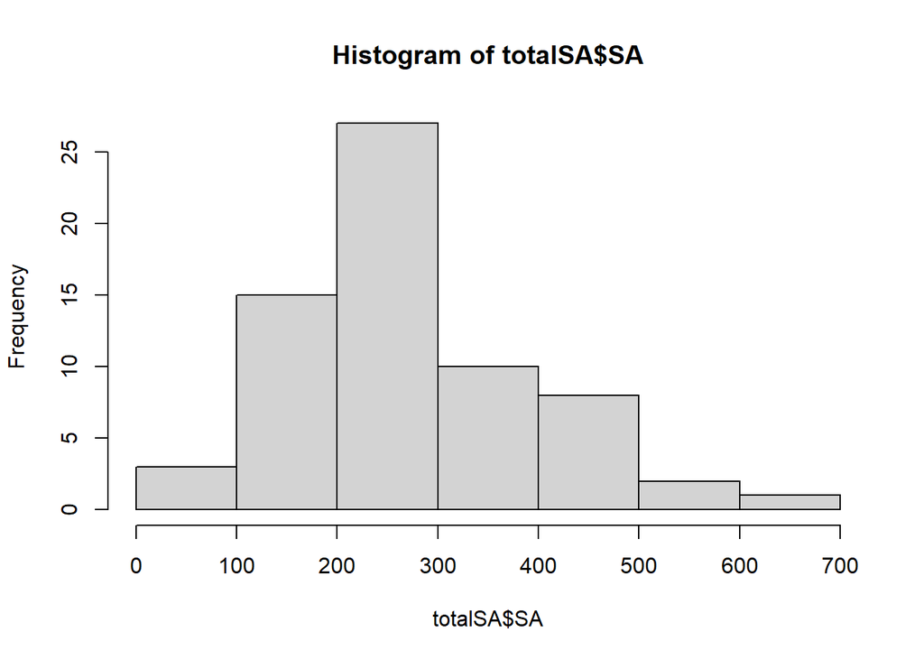

```r
# totalPerm <- adonis(formula = SA ~ treatment*timepoint*species, data = totalSA, method = "euclidian", permutations = 9999 )

#Testing normality of totalSA and totalChangeSA

hist(totalSA$SA)
```

```r
shapiro.test(totalSA$SA)
```

```
##
##  Shapiro-Wilk normality test
##
## data:  totalSA$SA
## W = 0.91666, p-value = 0.0002905
```

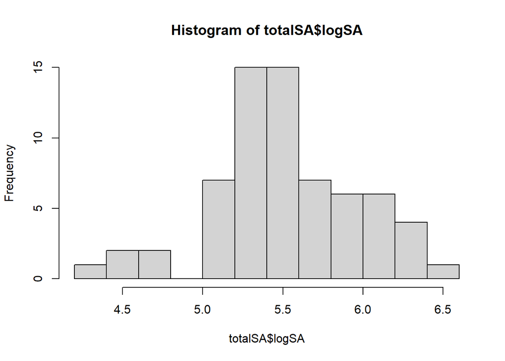

```r
#Significant so Data does not fit normal distribution
#log transform data

totalSA$logSA <- log(totalSA$SA)

#Re-testing normality
hist(totalSA$logSA)
```

```r
shapiro.test(totalSA$logSA)
```

```
##
##  Shapiro-Wilk normality test
##
## data:  totalSA$logSA
## W = 0.96999, p-value = 0.11
```

# Statistical Analyses

## With our newly formed dataset and our transformed data, we are now going to perform some Repeated Measures Analyses of variance using the `lmer()` function from the package `lme4`. We are testing our logtransformed raw SA data as well as our percent change data with **treatment** and **timepoint** as factors and **id** as a random effect.

```r
logTotalLM <- lmer(logSA ~ species*treatment*timepoint + (1 | id), totalSA)
logTotalLManova <- ranova(logTotalLM)
logTotalLManova
```

```
## ANOVA-like table for random-effects: Single term deletions
##
## Model:
## logSA ~ species + treatment + timepoint + (1 | id) + species:treatment + species:timepoint + treatment:timepoint + species:treatment:timepoint
##          npar  logLik    AIC   LRT Df Pr(>Chisq)
## <none>     20  15.641  8.718
## (1 | id)   19 -27.504 93.009 86.29  1  < 2.2e-16 ***
## ---
## Signif. codes:  0 '***' 0.001 '**' 0.01 '*' 0.05 '.' 0.1 ' ' 1
```

```r
eta_sq(logTotalLM, partial = TRUE)
```

```
## # Effect Size for ANOVA (Type III)
##
## Parameter                   | Eta2 (partial) |       95% CI
## -----------------------------------------------------------
## species                     |           0.24 | [0.00, 1.00]
## treatment                   |           0.84 | [0.76, 1.00]
## timepoint                   |           0.87 | [0.80, 1.00]
## species:treatment           |           0.32 | [0.12, 1.00]
## species:timepoint           |           0.10 | [0.00, 1.00]
## treatment:timepoint         |           0.76 | [0.65, 1.00]
## species:treatment:timepoint |           0.11 | [0.00, 1.00]
##
## - One-sided CIs: upper bound fixed at [1.00].
```

```r
r.squaredGLMM(logTotalLM)
```

```
##            R2m       R2c
## [1,] 0.5103739 0.9598677
```

```r
emmeans(logTotalLM, list(pairwise ~ timepoint), adjust = 'bonferroni')
```

```
## NOTE: Results may be misleading due to involvement in interactions
```

```
## $`emmeans of timepoint`
##  timepoint emmean    SE   df lower.CL upper.CL
##  T0          5.31 0.103 8.47     5.08     5.55
##  T3          5.58 0.103 8.47     5.35     5.82
##  T6          5.79 0.103 8.47     5.56     6.03
##
## Results are averaged over the levels of: species, treatment
## Degrees-of-freedom method: kenward-roger
## Confidence level used: 0.95
##
## $`pairwise differences of timepoint`
##  1       estimate     SE df t.ratio p.value
##  T0 - T3   -0.271 0.0301 40  -9.028  <.0001
##  T0 - T6   -0.483 0.0301 40 -16.075  <.0001
##  T3 - T6   -0.212 0.0301 40  -7.048  <.0001
##
## Results are averaged over the levels of: species, treatment
## Degrees-of-freedom method: kenward-roger
## P value adjustment: bonferroni method for 3 tests
```

```r
changeLM <- lmer(percentChange ~ species*treatment*timepoint + (1 | id), totalChange)
changeLManova <- anova(changeLM)
changeLManova
```

```
## Type III Analysis of Variance Table with Satterthwaite's method
##                             Sum Sq Mean Sq NumDF DenDF  F value    Pr(>F)
## species                        147      74     2     8   0.3582  0.709578
## treatment                    73360   73360     1    24 356.7125 6.542e-16 ***
## timepoint                    14934   14934     1    24  72.6165 1.014e-08 ***
## species:treatment             2519    1259     2    24   6.1234  0.007101 **
## species:timepoint             1108     554     2    24   2.6937  0.088023 .
## treatment:timepoint           8713    8713     1    24  42.3676 9.881e-07 ***
## species:treatment:timepoint    379     189     2    24   0.9205  0.411923
## ---
## Signif. codes:  0 '***' 0.001 '**' 0.01 '*' 0.05 '.' 0.1 ' ' 1
```

#Here we are creating a figure for the mean percent change of each species. Included in this figure are error bars derived from the standard deviation divided by the square root of the sample size (n)

```r
se <- function(x) sqrt(var(x) / length(x))

totalSAse <- totalSA %>%
  dplyr::select(timepoint, species, treatment, SA, logSA) %>%
  dplyr::group_by(timepoint, species, treatment) %>%
  dplyr::summarise(
    meanSA = mean(SA),
    sd = sd(SA),
    n = n(),
    se = sd/sqrt(n))
totalChangeSe <- totalChange %>%
dplyr::select(timepoint, species, treatment,percentChange) %>%
  dplyr::group_by(timepoint, species, treatment) %>%
  dplyr::summarise(
    meanPC = mean(percentChange),
    sd = sd(percentChange),
    n = n(),
    se = sd/sqrt(n))
```

```r
SApercentChange.1 <- ggplot(totalChangeSe, aes(x = treatment, y = meanPC, fill = timepoint)) +
  geom_bar(stat = "identity", position = position_dodge())+
  facet_wrap(~species)+
    ggtitle("Surface Area Percent Growth of D. labyrinthiformis, P. strigosa, and P. clivosa Over Six Months") + scale_x_discrete(labels=c("frag" = "Frag", "wild" = "Whole"))+scale_fill_manual(name="Time Point",values = c( "#EAA65D","#0D3B66"))+
    xlab("Treatment") + ylab("Percent Change (%)")+
  geom_errorbar( aes(x=treatment, ymin=meanPC-se, ymax=meanPC+se), position = position_dodge()) +
    ggtitle("Mean Percent Change in Surface Area of D. labyrinthiformis, P. strigosa, and P. clivosa Over Six Months") + scale_x_discrete(labels=c("frag" = "Frag", "wild" = "Whole"))+scale_fill_manual(name="Time Point",values = c("#0EBEBE","#9FA0FF"))+
    xlab("Treatment") + ylab("Percent Change (%)")
```

[output not shown]

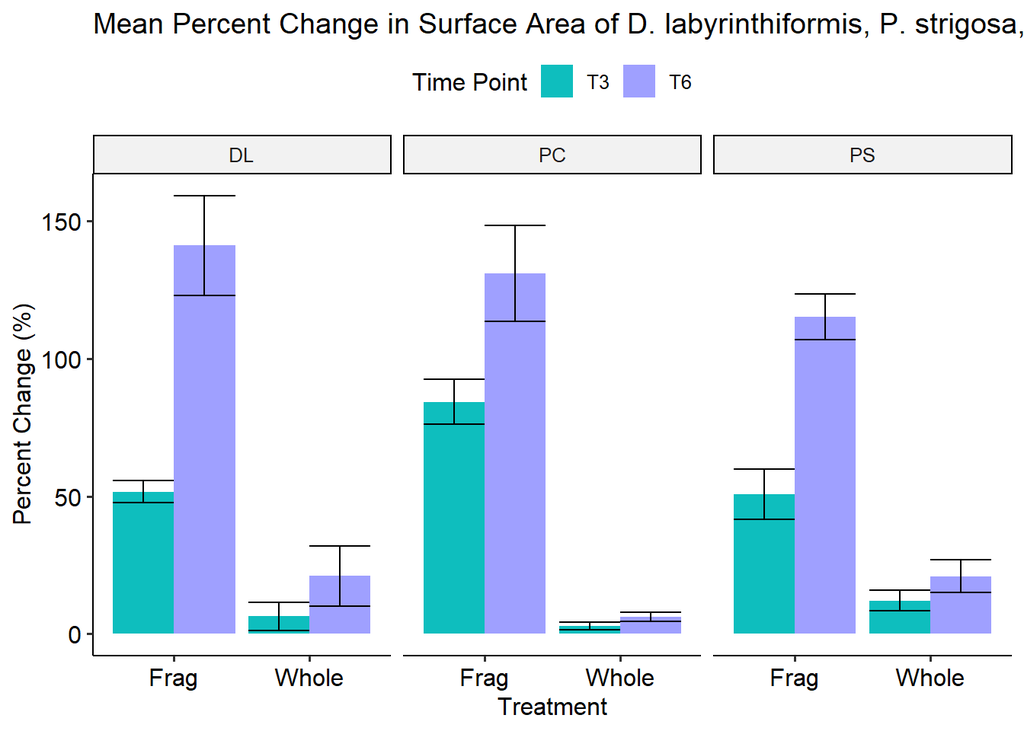

```r
SApercentChange.1
```

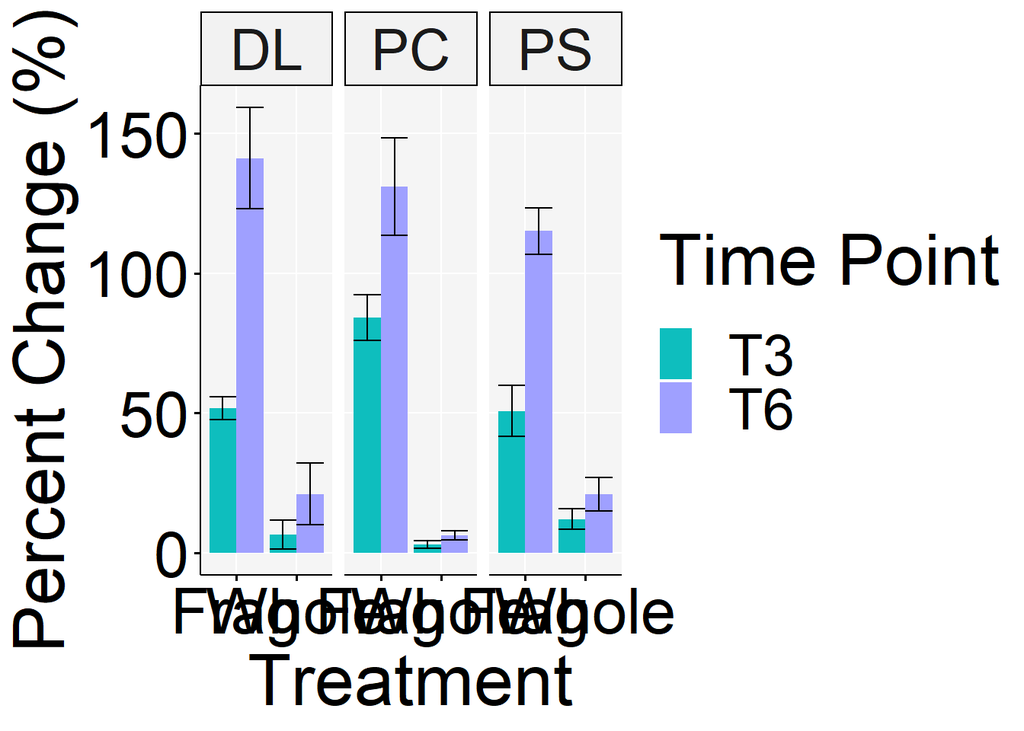

```r
SApercentChange<- SApercentChange.1 + theme(
  panel.grid.major = element_line(size = 0.5, linetype = 'solid', colour = "white"),
  panel.background = element_rect(fill = '#F5F5F5'),
  plot.title = element_blank(),
  axis.line = element_line(colour = "black"),
  axis.ticks = element_line(color="black"),
  text = element_text(size = 35, color="black"),
  axis.text.x=element_text(size = 31, color="black"),
  axis.text.y=element_text(size = 31, color="black"),
  legend.position = "right")

SApercentChange
```

```r
ggsave("../figures/SApercentChange.png", plot = SApercentChange, height = 15, width = 20, units = 'in',dpi = 600)
```

#Here we are creating a figure for the mean T0, T3, and T6 surface area of each species. Included in this figure are error bars derived from the standard deviation divided by the square root of the sample size (n)

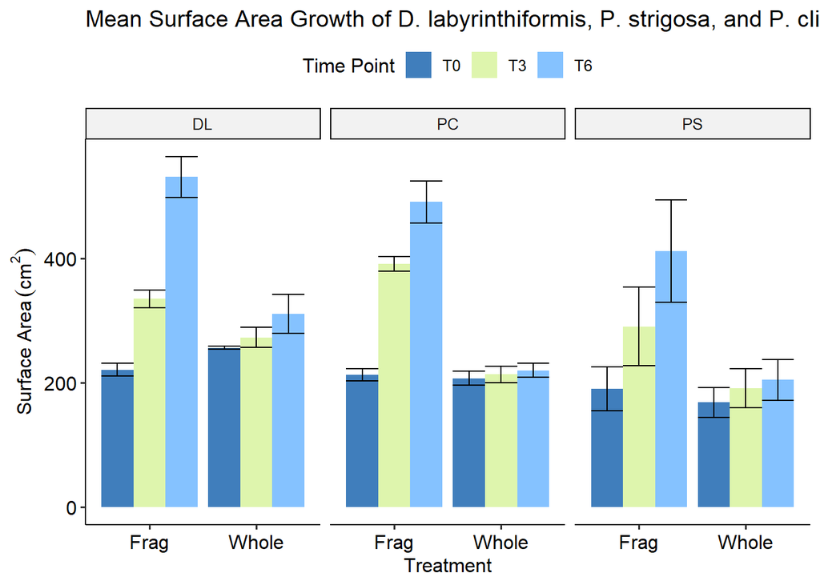

```r
SAgrowth.1 <- ggplot(data=totalSAse, aes(x = treatment, y = meanSA, fill = timepoint)) +
  geom_bar(stat = "identity", position = position_dodge(), alpha = 0.75)+
  geom_errorbar( aes(x=treatment, ymin=meanSA-se, ymax=meanSA+se), position = position_dodge())+
  facet_wrap(~species)+
  scale_fill_hue(name="Time Point") +
  labs(x = "Treatment", y = bquote("Surface Area" ~ (cm^2)),fill='Time Point') +
    ggtitle("Mean Surface Area Growth of D. labyrinthiformis, P. strigosa, and P. clivosa Over Six Months") + scale_fill_discrete(labels=c('Initial','T3','Final'))+scale_x_discrete(labels=c("frag" = "Frag", "wild" = "Whole"))+scale_fill_manual(values = c("#0053A6", "#D3F292", "#5CADFF"))
SAgrowth.1
```

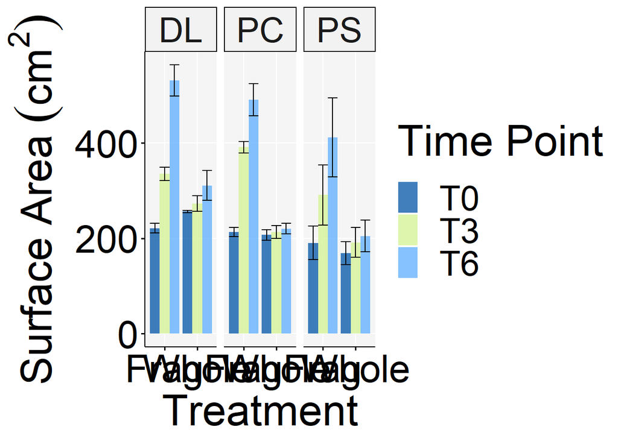

```r
SAgrowth <- SAgrowth.1 + theme(
  panel.grid.major = element_line(size = 0.5, linetype = 'solid', colour = "white"),
  panel.background = element_rect(fill = '#F5F5F5'),
  plot.title = element_blank(),
  axis.line = element_line(colour = "black"),
  axis.ticks = element_line(color="black"),
  text = element_text(size = 35, color="black"),
  axis.text.x=element_text(size = 31, color="black"),
  axis.text.y=element_text(size = 31, color="black"),
  legend.position = "right")


SAgrowth
```

```r
ggsave("../figures/SAgrowth.png", plot = SAgrowth, height = 15, width = 20, units = 'in',dpi = 600)
```